# Exam 6

readmitted_30d

readmitted_30d

readmitted_30d

readmitted_30d

readmitted_30d

readmitted_30d

Predictors

Odds Ratios

p

Odds Ratios

p

Odds Ratios

p

Odds Ratios

p

Odds Ratios

p

Odds Ratios

p

Odds Ratios

p

(Intercept)

0.22 ***

**<0.001**

5.11

0.284

6.96

0.207

85.74 **

**0.005**

106.61 **

**0.003**

131.21 **

**0.005**

105.29 **

**0.003**

age

1.01 ***

**<0.001**

1.01 ***

**<0.001**

1.01 ***

**<0.001**

1.01 ***

**<0.001**

1.01 ***

**<0.001**

1.01

0.392

1.01 ***

**<0.001**

distance to hospital km

1.01 **

**0.002**

1.01 **

**0.003**

1.01 **

**0.004**

1.01 **

**0.005**

1.01 **

**0.006**

1.01 **

**0.006**

1.01 **

**0.006**

bnp

1.00 ***

**<0.001**

1.00 ***

**<0.001**

1.00 ***

**<0.001**

1.00 ***

**<0.001**

1.00 ***

**<0.001**

1.00 ***

**<0.001**

sodium

0.97 **

**0.004**

0.97 **

**0.005**

0.96 ***

**0.001**

0.96 ***

**0.001**

0.96 ***

**0.001**

0.96 ***

**0.001**

creatinine

1.27 **

**0.008**

1.28 **

**0.006**

1.28 **

**0.006**

1.28 **

**0.007**

1.28 **

**0.007**

1.29 **

**0.006**

systolic bp

1.00 *

**0.032**

1.00 *

**0.025**

1.00

0.062

heart rate

0.99

0.062

0.99

0.069

1.00

0.120

ace inhibitor [1]

0.65 ***

**<0.001**

0.65 ***

**<0.001**

0.65 ***

**<0.001**

0.65 ***

**<0.001**

0.65 ***

**<0.001**

beta blocker [1]

0.72 ***

**<0.001**

0.73 ***

**<0.001**

0.73 ***

**<0.001**

0.73 ***

**<0.001**

0.73 ***

**<0.001**

adherence score

0.10 ***

**<0.001**

0.10 ***

**<0.001**

0.07 *

**0.028**

0.10 ***

**<0.001**

age × adherence score

1.00

0.787

sodium × diuretic1

1.00

0.228

Observations

2400

2400

2400

2400

2400

2400

2400

R<sup>2</sup> Tjur

0.014

0.048

0.063

0.095

0.092

0.092

0.093

AIC

3220.242

3148.229

3113.863

3037.113

3038.899

3040.827

3039.444

- p<0.05 ** p<0.01 *** p<0.001

```r
vif(model5.1) # check multicollinearity (all variance inflation factor near 1.0)
```

```
##                     age distance_to_hospital_km                     bnp
##                1.001524                1.001032                1.004837
##                  sodium              creatinine           ace_inhibitor
##                1.008361                1.003530                1.005275
##            beta_blocker         adherence_score
##                1.002845                1.008671
```

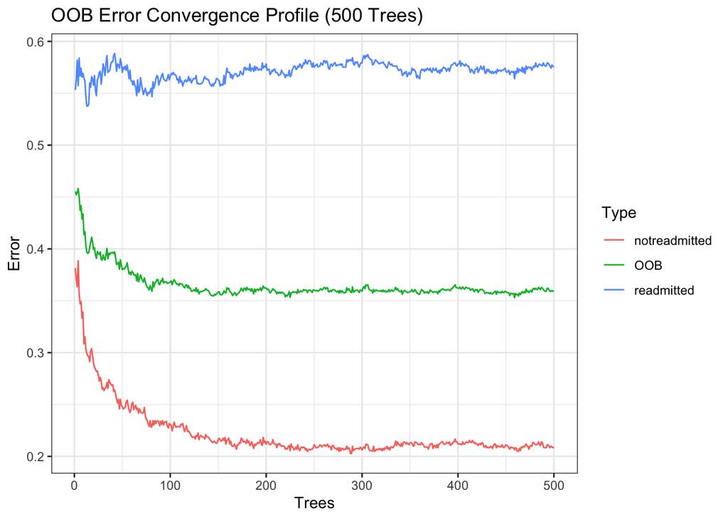

```r
# the final one is model 5.1
model_lr <- model5.1

# Second Model: Random Forest
set.seed(42)
#default model
model500 <- randomForest(readmitted_30d ~ ., data = train_dat, proximity=FALSE)

oob.error.data500 <- data.frame(
  Trees=rep(1:nrow(model500$err.rate), times=3),
  Type=rep(c("OOB", "notreadmitted", "readmitted"), each=nrow(model500$err.rate)),
  Error=c(model500$err.rate[,"OOB"],
          model500$err.rate[,"0"],
          model500$err.rate[,"1"]))

ggplot(data = oob.error.data500, aes(x = Trees, y = Error)) +
  geom_line(aes(color = Type)) +
  theme_bw() +
  labs(title = "OOB Error Convergence Profile (500 Trees)")
```

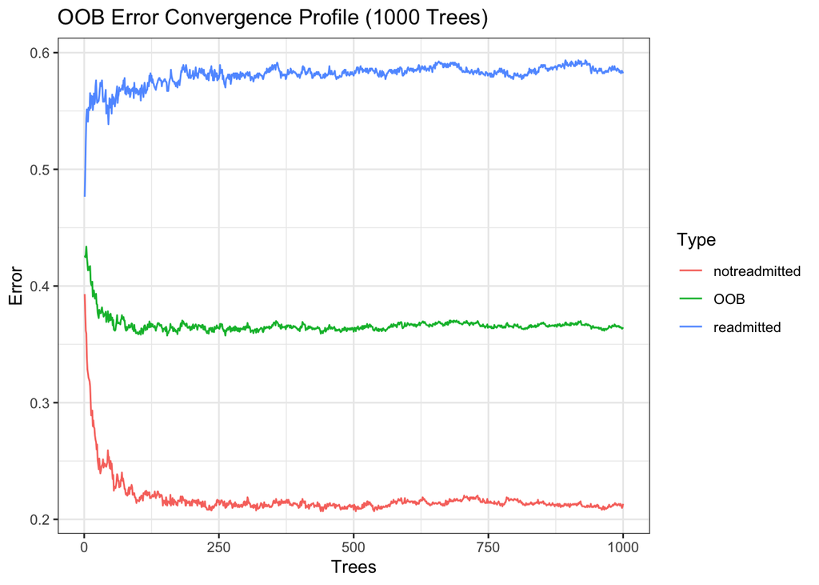

```r
#check how many tree is better
model1000 <- randomForest(readmitted_30d ~ ., data = train_dat,
                          ntree = 1000, proximity=FALSE)
oob.error.data1000 <- data.frame(
  Trees=rep(1:nrow(model1000$err.rate), times=3),
  Type=rep(c("OOB", "notreadmitted", "readmitted"), each=nrow(model1000$err.rate)),
  Error=c(model1000$err.rate[,"OOB"],
          model1000$err.rate[,"0"],
          model1000$err.rate[,"1"]))

ggplot(data = oob.error.data1000, aes(x = Trees, y = Error)) +
  geom_line(aes(color = Type)) +
  theme_bw() +
  labs(title = "OOB Error Convergence Profile (1000 Trees)") # no significant leap >> keep default tree
```

```r
# Tune mtry
max_pred <- ncol(train_dat)-1
oob.values <- vector(length=max_pred)

set.seed(233)
for(i in 1:max_pred) {
  temp.model <- randomForest(readmitted_30d ~ ., mtry=i,
                             data = train_dat, proximity=FALSE)
  oob.values[i] <- temp.model$err.rate[nrow(temp.model$err.rate), "OOB"]
}
oob.values #again no big difference >> use default setting
```

```
##  [1] 0.3862500 0.3633333 0.3629167 0.3750000 0.3666667 0.3783333 0.3716667
##  [8] 0.3750000 0.3791667 0.3729167 0.3737500 0.3762500 0.3729167 0.3787500
```

```r
# Final Model Definition
set.seed(42)
model_rf <- randomForest(readmitted_30d ~ . ,data = train_dat, proximity=FALSE)

# Model Evaluation on Test Set
log_preds <- predict(model_lr, newdata = test_dat, type = "response")
rf_preds <- predict(model_rf, newdata = test_dat, type = "prob")[, "1"]

# Optimize threshold
log_roc <- roc(test_dat$readmitted_30d, log_preds, quiet = TRUE, percent = TRUE)
rf_roc <- roc(test_dat$readmitted_30d, rf_preds, quiet = TRUE, percent = TRUE)
log_opt <- coords(log_roc, "best", ret = c("threshold", "specificity", "sensitivity"), best.method = "youden")
rf_opt <- coords(rf_roc, "best", ret = c("threshold", "specificity", "sensitivity"), best.method = "youden")

# Using clinical cutoff threshold of 0.40
log_outcome <- ifelse(log_preds > 0.4, 1, 0)
rf_outcome <- ifelse(rf_preds > 0.4, 1, 0)
log_comp_tab <- table(Predicted = log_outcome, Actual = test_dat$readmitted_30d)
rf_comp_tab <- table(Predicted = rf_outcome, Actual = test_dat$readmitted_30d)

# Compute final metrics
log_t_positive <- log_comp_tab["1", "1"]
log_t_negative <- log_comp_tab["0", "0"]
log_f_positive <- log_comp_tab["1", "0"]
log_f_negative <- log_comp_tab["0", "1"]

log_accuracy    <- (log_t_positive + log_t_negative) / sum(log_comp_tab)
log_sensitivity <- log_t_positive / (log_t_positive + log_f_negative)
log_specificity <- log_t_negative / (log_t_negative + log_f_positive)

rf_t_positive <- rf_comp_tab["1", "1"]
rf_t_negative <- rf_comp_tab["0", "0"]
rf_f_positive <- rf_comp_tab["1", "0"]
rf_f_negative <- rf_comp_tab["0", "1"]

rf_accuracy    <- (rf_t_positive + rf_t_negative) / sum(rf_comp_tab)
rf_sensitivity <- rf_t_positive / (rf_t_positive + rf_f_negative)
rf_specificity <- rf_t_negative / (rf_t_negative + rf_f_positive)

# Comparison
cat("\n--- Logistic Regression PERFORMANCE (THRESHOLD = 0.4) ---\n",
    "Accuracy    : ", round(log_accuracy, 4), "\n",
    "Sensitivity : ", round(log_sensitivity, 4), "\n",
    "Specificity : ", round(log_specificity, 4), "\n")
```

```
##
## --- Logistic Regression PERFORMANCE (THRESHOLD = 0.4) ---
##  Accuracy    :  0.65
##  Sensitivity :  0.68
##  Specificity :  0.6286
```

```r
cat("\n--- RANDOM FOREST PERFORMANCE (THRESHOLD = 0.4) ---\n",
    "Accuracy    : ", round(rf_accuracy, 4), "\n",
    "Sensitivity : ", round(rf_sensitivity, 4), "\n",
    "Specificity : ", round(rf_specificity, 4), "\n")
```

```
##
## --- RANDOM FOREST PERFORMANCE (THRESHOLD = 0.4) ---
##  Accuracy    :  0.6333
##  Sensitivity :  0.728
##  Specificity :  0.5657
```

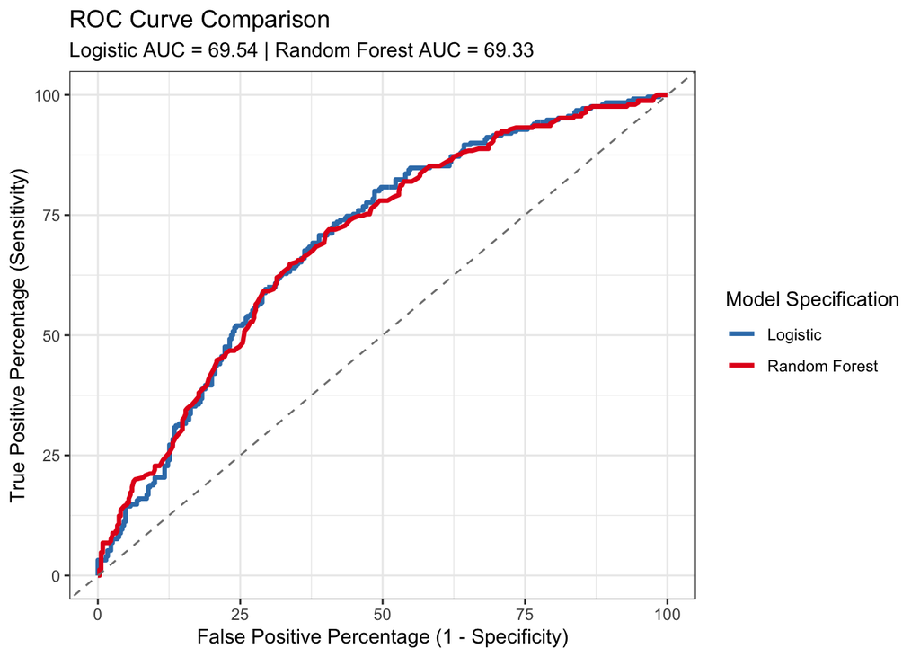

```r
# ROC Curve & AUC
ggroc(list(Logistic = log_roc, `Random Forest` = rf_roc), legacy.axes = TRUE, linewidth = 1.2) +
  geom_abline(slope = 1, intercept = 0, linetype = "dashed", color = "grey50") +
  theme_bw() +
  scale_color_manual(values = c("Logistic" = "#377eb8", "Random Forest" = "#e41a1c")) +
  labs(title = "ROC Curve Comparison",
       subtitle = paste0("Logistic AUC = ", round(log_roc$auc, 2),
                         " | Random Forest AUC = ", round(rf_roc$auc, 2)),
       x = "False Positive Percentage (1 - Specificity)",
       y = "True Positive Percentage (Sensitivity)",
       color = "Model Specification")
```

```r
# Variable Importance Plot (OR and absolute z-values)
tbl_regression(model_lr, exponentiate = TRUE) #creat summary table
```

| **Characteristic** | **OR** | **95% CI** | **p-value** |
| --- | --- | --- | --- |
| age | 1.01 | 1.01, 1.02 | <0.001 |
| distance_to_hospital_km | 1.01 | 1.00, 1.01 | 0.006 |
| bnp | 1.00 | 1.00, 1.00 | <0.001 |
| sodium | 0.96 | 0.94, 0.98 | <0.001 |
| creatinine | 1.28 | 1.07, 1.53 | 0.007 |
| ace_inhibitor |  |  |  |
| 0 | — | — |  |
| 1 | 0.65 | 0.55, 0.77 | <0.001 |
| beta_blocker |  |  |  |
| 0 | — | — |  |
| 1 | 0.73 | 0.61, 0.86 | <0.001 |
| adherence_score | 0.10 | 0.06, 0.17 | <0.001 |

Abbreviations: CI = Confidence Interval, OR = Odds Ratio

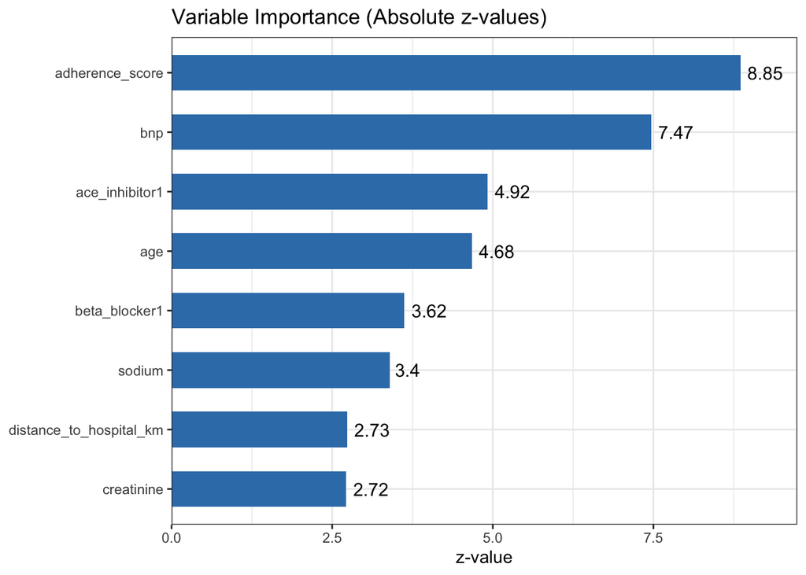

```r
coef_mod <- summary(model_lr)$coefficients[-1, ]
z_df <- data.frame(
  Variable = rownames(coef_mod),
  Importance = abs(coef_mod[, "z value"])
)

ggplot(z_df, aes(x = reorder(Variable, Importance), y = Importance)) +
  geom_col(fill = "#377eb8", width = 0.6) +
  geom_text(aes(label = round(Importance, 2)),hjust = -0.2, size = 4) +
  coord_flip() +
  theme_bw() +
  labs(title = "Variable Importance (Absolute z-values)", x = NULL, y = "z-value") +
  scale_y_continuous(expand = expansion(mult = c(0, 0.1)))
```